# Clustering Goals in the German Bundesliga

R

machine learning

soccer

Author

Maximilian Klemp

Published

July 15, 2023

Abstract

Examining soccer teams’ playing styles by identifying clusters of goals scored in the German Bundesliga.

```r
library(tidyverse)
library(flexclust)
options(scipen=999)

path <- '/home/max/drive/dshs/teaching/abschlussarbeiten/Herrmann_Sven/data/Rohdaten.csv'

dat <- read.csv(path)

colnames(dat) <- c("mday", "goalid", "home", "away", "team", "home_score", "away_score", "interval", "tactical_context", "passes_before_goal", "previous_action",
                   "action_leading2goal", "pressure", "preassist", "assist", "scorer", "zone_preassist", "zone_assist", "zone_goal")

df_cluster <- dat %>%
  select(home, away, team, tactical_context, passes_before_goal, previous_action, action_leading2goal, pressure, zone_preassist, zone_assist, zone_goal) %>%
  mutate_all(as.factor) %>%
  mutate(
    tactical_context = factor(tactical_context, levels = c("Freistoß (direkt)", "Eckstoß (outswing)", "Aus dem Spiel", "Umschaltspiel nach Ballgewinn",  "Eckstoß (kurz)", "Eckstoß (inswing)", "Freistoß (indirekt)", "Einwurf", "Strafstoß", ""), labels = c("directFreekick", "outswingCornerkick", "openPlay", "counterAttack", "shortCornerkick", "inswingCornerkick", "indirectFreekick", "throwin", "penalty", "counterAttack")
                              ),
    action_leading2goal = factor(action_leading2goal, levels = c("Ballkontrolle + Dribbling + Schuss", "Ballkontrolle + Schuss", "Schuss (direkt)", "Kopfball"), labels = c("dribbleAndShot", "receptionAndShot", "directShot", "header")
                                 ),
    pressure = factor(pressure, levels = c("No-Pressure", "Pressure"), labels = c("noPressure", "pressure")),
    previous_action = factor(previous_action, levels = c("Pass < (10m)", "Shot", "Cross", "Pass (10 - 20m)", "n.a", "Kopf"), labels = c("shortPass", "shot", "cross", "longPass", "none", "header"))
    )
```

Football teams adopt different strategies. The way in which they create their goal opportunities generates a footprint of their playing style. Identifying an opponent’s playing style can help to prepare for a match against that team. Since goals can be described by a multitude of features, it is unlikely to observe the same goal twice and to identify styles by looking at the individual goals. However, it is possible to find groups of similar goals. The method from the realm of Machine Learning that is best suitable for this purpose is **Cluster Analysis**. This notebook demonstrates how to apply this method to a dataset of goals scored in the German Bundesliga season 2022/2023.

The data used in this notebook was created by annotating the videos of all 971 goals scored in the 306 matches of the season. They have been assigned different features, e.g. the tactical context from which the goals were scored or the number of passes played before the goal. From these features of each goal, clusters of goals shall be identified, revealing different prototypical playing styles in the creation of goals. Using these clusters, preferred goal scoring styles are examined per team.

A snippet of the raw dataset is displayed below.

```r
knitr::kable(head(df_cluster))
```

| home | away | team | tactical_context | passes_before_goal | previous_action | action_leading2goal | pressure | zone_preassist | zone_assist | zone_goal |
| --- | --- | --- | --- | --- | --- | --- | --- | --- | --- | --- |
| SGE | FCB | FCB | directFreekick | 0 | shortPass | directShot | noPressure | 12 | 15 | 6 |
| SGE | FCB | FCB | outswingCornerkick | 4 | shot | directShot | pressure | 20 | 18 | 9 |
| SGE | FCB | FCB | openPlay | 7+ | cross | header | noPressure | 11 | 17 | 9 |
| SGE | FCB | FCB | openPlay | 7+ | shortPass | directShot | noPressure | 18 | 24 | 14 |
| SGE | FCB | FCB | counterAttack | 5 | shortPass | receptionAndShot | noPressure | 14 | 14 | 9 |
| SGE | FCB | SGE | counterAttack | 4 | shortPass | directShot | noPressure | 11 | 14 | 5 |

## Creating numerical features

In order to find different, prototypical categories of goals and to assign them to teams,we will perform **k-means clustering** on the data. The data that we got from our video analysis consists of 8 categorical features for each goal. Since cluster analysis works with numerical data only, we have to transform our categorical variables into numerical ones. This is achieved using a two-step process, by (1) applying **One-Hot-Encoding** on the categorical variables and then performing **dimensionality reduction** on the binary variables. As a side note, technically there are options to perform clustering on categorical variables (like k-modes), but experimenting with both yielded better results for the numerical approach.

### One-Hot Encoding

First, our **8 categorical variables** are transformed into a so-called **dummy matrix**. This means that for each variable, a separate column is created for each possible category. Each column then contains only the values $0$ or $1$. Below is a snippet of the first few rows and columns of this matrix:

```r
df_cluster <- df_cluster %>%
  select(-home, -away, -team)
mat <- model.matrix(~. - 1, data = df_cluster)
df_dummies <- as.data.frame(mat)
df_dummies[,1:10] %>%
  head() %>%
  knitr::kable()
```

| tactical_contextdirectFreekick | tactical_contextoutswingCornerkick | tactical_contextopenPlay | tactical_contextcounterAttack | tactical_contextshortCornerkick | tactical_contextinswingCornerkick | tactical_contextindirectFreekick | tactical_contextthrowin | tactical_contextpenalty | passes_before_goal1 |
| --- | --- | --- | --- | --- | --- | --- | --- | --- | --- |
| 1 | 0 | 0 | 0 | 0 | 0 | 0 | 0 | 0 | 0 |
| 0 | 1 | 0 | 0 | 0 | 0 | 0 | 0 | 0 | 0 |
| 0 | 0 | 1 | 0 | 0 | 0 | 0 | 0 | 0 | 0 |
| 0 | 0 | 1 | 0 | 0 | 0 | 0 | 0 | 0 | 0 |
| 0 | 0 | 0 | 1 | 0 | 0 | 0 | 0 | 0 | 0 |
| 0 | 0 | 0 | 1 | 0 | 0 | 0 | 0 | 0 | 0 |

## Dimensionality reduction

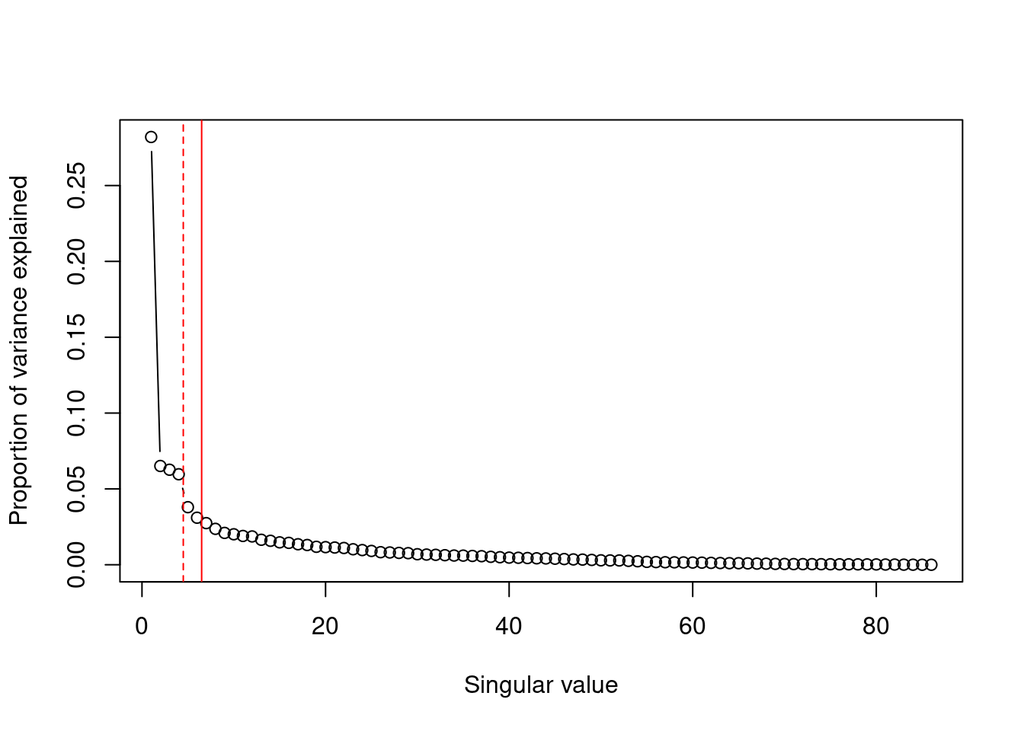

```r
svd_result <- svd(df_dummies)

prop_var_explained <- svd_result$d^2 / sum(svd_result$d^2)
cum_var_explained  <- cumsum(prop_var_explained)
plot(prop_var_explained, type = "b", xlab = "Singular value", ylab = "Proportion of variance explained")

#plot(cumsum(prop_var_explained), type = "b", xlab = "Anzahl Dimensionen", ylab = "Kumulierte erklärte Varianz")
abline(v=4.5, col="red", lty = 2)
abline(v=6.5, col="red")
```

Natürlicherweise wird durch jede zusätzliche Dimension auch mehr Varianz erklärt. Allerdings nimmt bei hochdimensionalen Daten ab einer gewissen Dimension meist die zusätzlich erklärte Varianz ab. Ein “Ellenbogenpunkt”, welcher eine rapide Änderung der Steigung des Graphen anzeigt, identifiziert die kleinste Dimensionalität, welche noch einen signifikanten Informationsgewinn bedeutet. Nach diesem Punkt flacht die Kurve deutlich ab und jede zusätzliche Dimension verursacht nur noch einen marginalen zusätzlichen Informationsgewinn. Der “Ellenbogenpunkt” ist nur selten eindeutig zu bestimmen. In unserem Diagramm kommen prinzipiell zwei Punkte infrage, welche durch die gestrichelte und die durchgezogene Linie angezeigt werden. Da es sich insgesamt um ein hochdimensionales Problem handelt, wird die durchgezogene Linie gewählt, weil insgesamt bis hierhin noch zusätzliche Varianz erklärt wird und danach der Graph eindeutig abflacht. Diese Linie zeigt eine Dimensionalität von 6 an. Diese wird verwendet, um einen neuen, dimensionsreduzierten Datensatz mit 6 Variablen zu ermitteln. Diese Dimensionen sind nun nicht mehr interpretierbar, können aber für die Clusteranalyse verwendet werden. Eine Übersicht über den neuen Datensatz sieht folgendermaßen aus:

```r
## NOTES:
  # based on 80% rule, 22 dimensions should be retained
  # based on visual elbow point, 7 should be retained ( or 29)

# Choose the number of dimensions to retain
num_dims <- 6

# Project the data onto these dimensions
reduced_data <- as.matrix(df_dummies) %*% svd_result$v[, 1:num_dims]
knitr::kable(head(reduced_data))
```

| -0.452979 | -0.5566330 | 0.0899807 | -0.2644000 | 0.4703923 | -0.2242417 |
| --- | --- | --- | --- | --- | --- |
| -1.686565 | -0.6473897 | 0.2128024 | -0.4694705 | -0.0475723 | 0.3277312 |
| -1.305201 | 0.4821976 | -1.1560128 | -0.4364203 | -0.4972119 | 0.0646575 |
| -0.891784 | -0.7588065 | -0.9605267 | 0.0877693 | 0.8343932 | 0.2202717 |
| -1.127883 | -0.0974868 | 0.6735477 | 0.7246956 | -0.9630310 | -0.8314999 |
| -1.004543 | -0.5489809 | 0.8316487 | 0.6467081 | 0.4734059 | -0.8147062 |

## Clusteranalyse

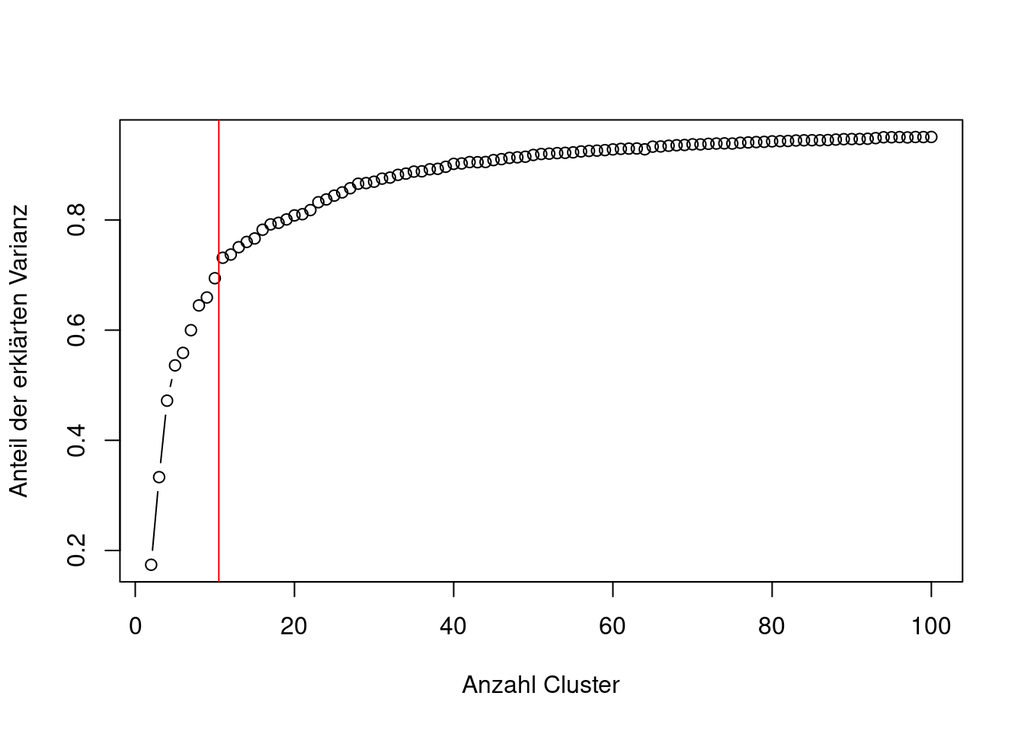

```r
################### CLUSTERING
# Create an empty vector to store the total within-cluster sum of squares for each k
tot_withinss <- numeric(99)
betweenss    <- numeric(99)
totss        <- numeric(99)

# Loop over different numbers of clusters
for (k in 2:100) {
  set.seed(123) # For reproducibility
  kmeans_result <- kmeans(reduced_data, centers = k)
  tot_withinss[k-1] <- kmeans_result$tot.withinss
  betweenss[k-1] <- kmeans_result$betweenss
  totss[k-1] <- kmeans_result$totss
}

# Plot total within-cluster sum of squares as a function of the number of clusters
var_explained <- betweenss / totss
plot(2:100, var_explained, type = "b", xlab = "Anzahl Cluster", ylab = "Anteil der erklärten Varianz")
abline(v=10.5, col = 'red')
```

```r
# with new dimensionality in SVD, 10 clusters appear
# NOTES: gain in variance explained suggests 16 clusters
# tot within ss plot suggests 17 clusters

# NOTES: not necessarily interpretable goal types;
#   assigning goals to clusters and then counting per team or per player might also be interesting
```

```r
#### FINAL IMPLEMENTATION
k <- 10
kmeans_result <- kmeans(reduced_data, centers = k)
dat$cluster <- kmeans_result$cluster
df_cluster$cluster <- kmeans_result$cluster
```

## Interpretation der Cluster

Um zunächst eine Interpretation der 10 verschiedenen Cluster zu ermöglichen, wird nachfolgend für jedes Cluster ein “prototypisches” Tor ermittelt. Dazu werden jeweils alle Beobachtungen pro Cluster gesammelt und für jede der 8 Variablen im Originaldatensatz, welche die Tore semantisch beschreiben, der Modus ermittelt. Der Modus gibt jene Kategorie einer Variable an, welche im Datensatz am häufigsten auftritt. Auf diese Weise kann das “häufigste” Tor im Datensatz ermittelt werden. Es folgt eine Tabelle, welche pro Cluster die häufigste Kombination von Variablen, und somit jeweils ein “prototypisches” Tor zeigt.

```r
mode <- function(x) {
  ux <- unique(x)
  ux[which.max(tabulate(match(x, ux)))]
}

prototypes <- df_cluster %>%
  group_by(cluster) %>%
  summarise_all(mode)

knitr::kable(prototypes)
```

| cluster | tactical_context | passes_before_goal | previous_action | action_leading2goal | pressure | zone_preassist | zone_assist | zone_goal |
| --- | --- | --- | --- | --- | --- | --- | --- | --- |
| 1 | openPlay | 7+ | shortPass | directShot | pressure | 14 | 18 | 9 |
| 2 | directFreekick | 1 | shortPass | directShot | noPressure | n.a | 14 | 5 |
| 3 | counterAttack | 3 | shortPass | receptionAndShot | pressure | 14 | 14 | 9 |
| 4 | openPlay | 1 | cross | header | pressure | n.a | 16 | 9 |
| 5 | openPlay | 7+ | shortPass | receptionAndShot | pressure | 14 | 14 | 9 |
| 6 | counterAttack | 2 | shortPass | directShot | pressure | 16 | 18 | 14 |
| 7 | penalty | 0 | shortPass | directShot | noPressure | n.a | 18 | 9 |
| 8 | counterAttack | 2 | shortPass | dribbleAndShot | pressure | 14 | 14 | 5 |
| 9 | inswingCornerkick | 1 | cross | header | pressure | n.a | 16 | 14 |
| 10 | counterAttack | 4 | shortPass | directShot | pressure | 14 | 18 | 9 |

Die nachfolgende Grafik zeigt die Anzahl erzielter Tore pro Cluster über die gesamte Stichprobe hinweg:

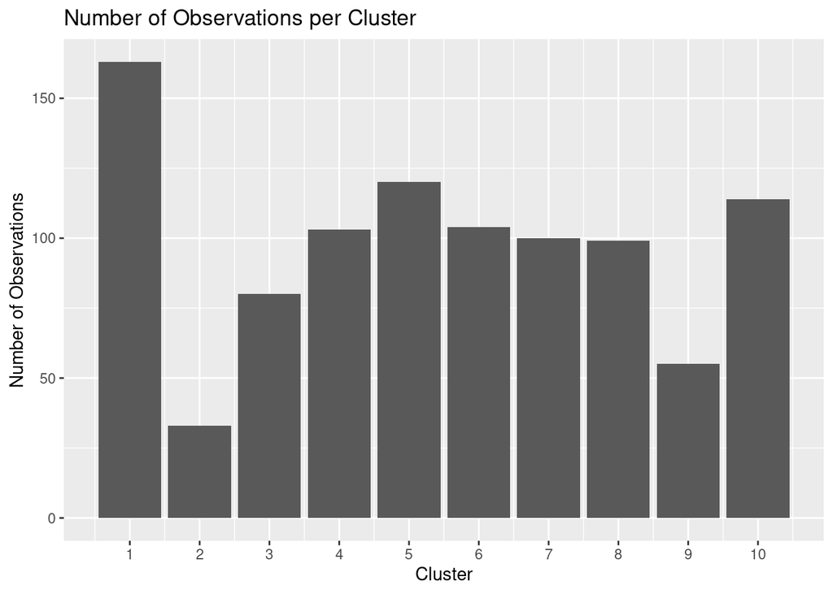

```r
df_cluster_perteam <- dat %>%
  group_by(team, cluster) %>%
  summarise(count = n(), .groups = "drop") %>%
  group_by(team) %>%
  mutate(proportion = round(count / sum(count), 2))

# Distribution of goals across Clusters
ggplot(df_cluster_perteam, aes(x = cluster, y = count)) +
  geom_bar(stat = "identity") +
  labs(title = "Number of Observations per Cluster",
       x = "Cluster",
       y = "Number of Observations") +
  scale_x_continuous(breaks=1:10)
```

## Analyse der Arten erzielter Tore in Abhängigkeit der Mannschaften

Die nachfolgende Tabelle zeigt die Verteilung von Toren in die verschiedenen Cluster in Abhängigkeit von den Mannschaften:

```r
df_abs_values <- df_cluster_perteam %>%
  select(-proportion) %>%
  pivot_wider(names_from = cluster, values_from = count, names_prefix = "c") %>%
  replace(is.na(.), 0)

df_rel_values <- df_cluster_perteam %>%
  select(-count) %>%
  pivot_wider(names_from = cluster, values_from = proportion, names_prefix = "c") %>%
  replace(is.na(.), 0)

teams <- df_rel_values$team
df_rel_values$team <- NULL
baseline_probs <- round(table(dat$cluster) / dim(dat)[1], 3)

mat <- as.matrix(df_rel_values)
df_diffs <- round(data.frame(mat - matrix(rep(baseline_probs, 18), nrow=18, ncol=10, byrow = TRUE)), 2)
df_diffs$team <- teams

df_diffs_long <- df_diffs %>%
  pivot_longer(cols = c1:c10, names_to = "cluster", values_to = "proportion_diff") %>%
  mutate(cluster = as.numeric(gsub("c", "", cluster)))

knitr::kable(df_abs_values)
```

| team | c1 | c2 | c3 | c4 | c5 | c6 | c7 | c8 | c9 | c10 |
| --- | --- | --- | --- | --- | --- | --- | --- | --- | --- | --- |
| B04 | 11 | 2 | 8 | 5 | 10 | 6 | 6 | 4 | 1 | 4 |
| BMG | 13 | 1 | 6 | 5 | 5 | 2 | 3 | 7 | 1 | 9 |
| BOC | 3 | 0 | 2 | 3 | 4 | 6 | 5 | 4 | 6 | 7 |
| BSC | 1 | 2 | 4 | 3 | 5 | 4 | 7 | 3 | 2 | 11 |
| BVB | 17 | 4 | 5 | 6 | 19 | 8 | 5 | 8 | 4 | 7 |
| FCA | 6 | 0 | 3 | 2 | 4 | 5 | 5 | 5 | 5 | 7 |
| FCB | 24 | 1 | 7 | 4 | 21 | 13 | 3 | 12 | 2 | 5 |
| FCU | 8 | 3 | 3 | 10 | 2 | 7 | 4 | 4 | 3 | 7 |
| KOE | 9 | 1 | 2 | 6 | 3 | 4 | 8 | 5 | 5 | 6 |
| M05 | 12 | 3 | 2 | 4 | 3 | 8 | 5 | 5 | 7 | 5 |
| RBL | 8 | 3 | 9 | 6 | 7 | 6 | 6 | 9 | 2 | 8 |
| S04 | 1 | 2 | 1 | 7 | 2 | 5 | 4 | 5 | 1 | 7 |
| SCF | 9 | 3 | 2 | 9 | 6 | 5 | 9 | 2 | 3 | 3 |
| SGE | 8 | 3 | 7 | 4 | 10 | 8 | 6 | 5 | 2 | 5 |
| SVW | 11 | 2 | 3 | 10 | 4 | 2 | 6 | 4 | 3 | 6 |
| TSG | 9 | 1 | 4 | 7 | 3 | 5 | 7 | 5 | 2 | 5 |
| VFB | 3 | 1 | 6 | 4 | 7 | 4 | 5 | 6 | 3 | 6 |
| WOB | 10 | 1 | 6 | 8 | 5 | 6 | 6 | 6 | 3 | 6 |

## Verteilung der Cluster pro Mannschaft

Die absoluten Häufigkeiten der Tore pro Cluster pro Mannschaft werden durch die absolute Anzahl geschossener Tore pro Mannschaft verzerrt. Um ein Bild über die Spielstile der Mannschaften zu zeichnen, müssen die relativen Häufigkeiten von Toren pro Cluster in Abhängigkeit von der Gesamtzahl geschossener Tore pro Mannschaft betrachtet werden. Die nachfolgende Heatmap zeigt daher die relative Häufigkeit von Toren in den 10 Clustern in Abhängigkeit von der Mannschaft. Daraus lassen sich sowohl Rückschlusse auf die grundlegende Verteilung von Toren auf die 10 Cluster ziehen als auch auf Besonderheiten im Spielstil einzelner Mannschaften.

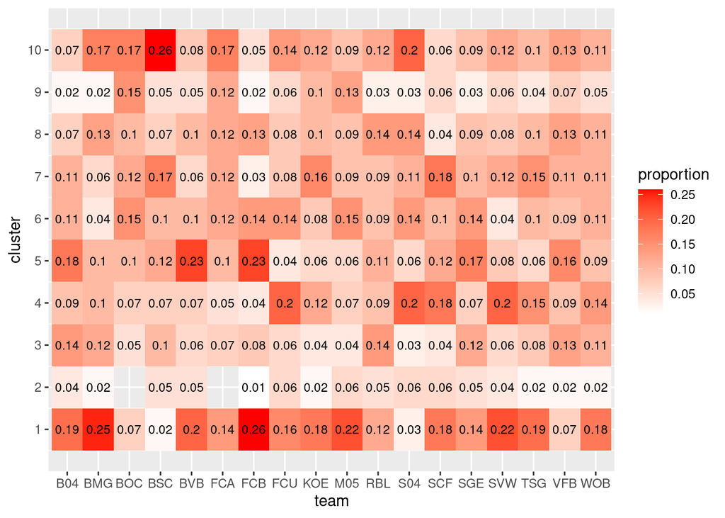

```r
## Distribution of clusters per team
ggplot(df_cluster_perteam, aes(team, cluster)) +
  geom_tile(aes(fill=proportion)) +
  geom_text(aes(label=proportion), size = 3) +
  scale_fill_gradient(low = "white", high = "red") +
  scale_y_continuous(breaks = 1:10)
```

In dieser Grafik zeigen sich bereits Muster bestimmter Mannschaften. Allerdings beinhaltet sie auch die Basisrate einzelner Cluster. Daher wird im Folgenden noch die durchschnittliche Häufigkeit von Toren in den 10 Clustern über alle Mannschaften hinweg von den individuellen relativen Häufigkeiten abgezogen, sodass für jede Mannschaft dargestellt wird, wie stark die Häufigkeit der Torerzielung vom Durchschnitt abweicht.

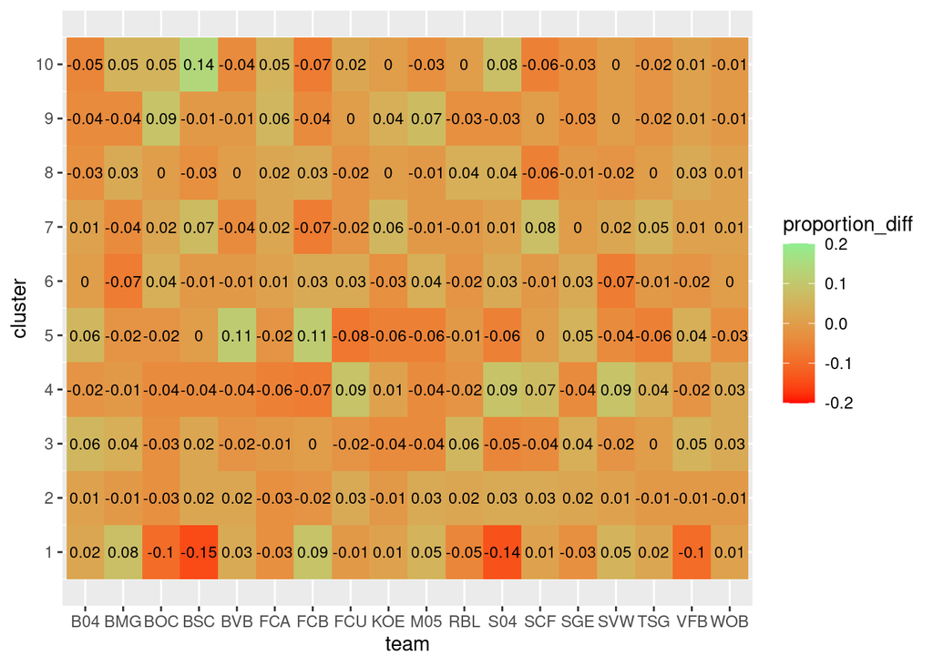

```r
## Deviation of teams' distribution from baseline distribution
ggplot(df_diffs_long, aes(team, cluster)) +
  geom_tile(aes(fill=proportion_diff)) +
  geom_text(aes(label=proportion_diff), size = 3) +
  #scale_fill_viridis(limits = c(-.2, .151), oob = scales::squish)
  scale_fill_gradient(low = "red", high = "lightgreen", limits = c(-.2, .2), oob = scales::squish) +
  scale_y_continuous(breaks = 1:10)
```

```r
#write.csv(df_cluster, '/home/max/sciebo/local/dshs/teaching/abschlussarbeiten/Herrmann_Sven/data/Rohdaten_mitCluster.csv')
#write.csv(df_abs_values, '/home/max/sciebo/local/dshs/teaching/abschlussarbeiten/Herrmann_Sven/data/Cluster_perTeam_absolut.csv')
#write.csv(df_rel_values, '/home/max/sciebo/local/dshs/teaching/abschlussarbeiten/Herrmann_Sven/data/Cluster_perTeam_relativ.csv')
#write.csv(df_diffs, '/home/max/sciebo/local/dshs/teaching/abschlussarbeiten/Herrmann_Sven/data/Cluster_perTeam_Differenz.csv')
```